# Презентация по лабораторной работе №8

Модель конкуренции двух фирм

Вакутайпа Милдред

1032239009@rudn.ru

Российский университет дружбы народов

2026-05-23

# Информация

## Докладчик

- Вакутайпа Милдред
- НКНбд-01-23
- студентка кафедры матеиатического моделирования и искуcственного интеkлекта
- Российский университет дружбы народов им. П. Лумумбы
- 1032239009@rudn.ru
- https://wakutaipa.github.io/

# Цель работы

Построить модели конкуренции для двух фирм для двух разных случаев.

# Задание

## Случай 1

- Рассмотрим две фирмы.
- Считаем, что в рамках нашей модели конкурентная борьба ведётся только рыночными методами.
- Будем считать, что постоянные издержки пренебрежимо малы, и в модели учитывать не будем. В этом случае динамика изменения объемов продаж фирмы 1 и фирмы 2 описывается следующей системой уравнений:

## Случай 1

$$\dfrac{dM_1}{d\theta} = M_1 - \dfrac{b}{c_1}M_1M_2 - \dfrac{a_1}{c_1}M_1^2$$

$$\dfrac{dM_2}{d\theta} = \dfrac{c_2}{c_1}M_2 - \dfrac{b}{c_1}M_1M_2 - \dfrac{a_2}{c_1}M_2^2$$

где
$$a_1 = \dfrac{p_cr}{\tau_1^2 p_1^2 Nq}, a_2 = \dfrac{p_cr}{\tau_2^2p_2^2 Nq}, b = \dfrac{p_cr}{\tau_1 \tau_2 p_1 p_2 Nq}, c_1 = \dfrac{p_cr - p_1}{\tau_1 p_1}, c_2 = \dfrac{p_cr - p_2}{\tau_2 p_2}$$

Также введена нормировка $t=c_1\theta$.

## Случай 2

- Рассмотрим модель, когда, помимо экономического фактора влияния (изменение себестоимости, производственного цикла, использование кредита и т.п.), используются еще и социально психологические факторы – формирование общественного предпочтения одного товара другому, не зависимо от их качества и цены.
- В этом случае взаимодействие двух фирм будет зависеть друг от друга, соответственно коэффициент перед $M_1M_2$ будет отличаться. Пусть в рамках рассматриваемой модели динамика изменения объемов продаж фирмы 1 и фирмы 2 описывается следующей системой уравнений:

## Случай 2

$$\dfrac{dM_1}{d\theta} = M_1-\dfrac{b}{c_1}M_1M_2-\dfrac{a_1}{c_1}M_1^2$$

$$\dfrac{dM_2}{d\theta} = \dfrac{c_2}{c_1}M_2-(\dfrac{b}{c_1}+0.00094)M_1M_2-\dfrac{a_2}{c_1}M_2^2$$

Для обоих случаев рассмотрим задачу со следующими начальными условиями и параметрами:

$$M(0)_1=4.4, M(0)_2=3.1, p_{cr}=33, N=44, q=1, \tau_1=22, \tau_2=13, \tilde{p_1}=7.7, \tilde{p_2}=10.7$$

## Задачи

1. Постройте графики изменения оборотных средств фирмы 1 и фирмы 2 без учета постоянных издержек и с веденной нормировкой для случая 1
2. Постройте графики изменения оборотных средств фирмы 1 и фирмы 2 без учета постоянных издержек и с веденной нормировкой для случая 2

# Теоретическое введение

Для построения модели конкуренции хотя бы двух фирм необходимо рассмотреть модель одной фирмы. Вначале рассмотрим модель фирмы, производящей продукт долговременного пользования, когда цена его определяется балансом спроса и предложения. Примем, что этот продукт занимает определенную нишу рынка и конкуренты в ней отсутствуют.

Обозначим: $N$ – число потребителей производимого продукта. $S$ – доходы потребителей данного продукта. Считаем, что доходы всех потребителей одинаковы.

## Теоретическое введение

$M$ – оборотные средства предприятия $\tau$ – длительность производственного цикла $p$ – рыночная цена товара p̃ – себестоимость продукта, то есть переменные издержки на производство единицы продукции. $\delta$ – доля оборотных средств, идущая на покрытие переменных издержек κ – постоянные издержки, которые не зависят от количества выпускаемой продукции

## Теоретическое введение

Q(S/p) - функция спроса, зависящая от отношения дохода S к цене p. Она равна количеству продукта, потребляемого одним потребителем в единицу времени. Функцию спроса товаров долговременного использования часто представляют в простейшей форме:

$$Q = q - k\frac{p}{s} = q{1-\frac{p}{p_cr}}$$

где q – максимальная потребность одного человека в продукте в единицу времени. Эта функция падает с ростом цены и при p = pcr (критическая стоимость продукта) потребители отказываются от приобретения товара. Величина pcr = Sq/k. Параметр k – мера эластичности функции спроса по цене.

# Выполнение лабораторной работы

До начала работы я установила необходимые пакеты с помощью DrWatson.

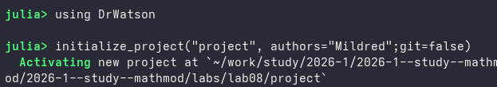

Рисунок 1: Создание проекта

## Выполнение лабораторной работы

Далее я использовала julia чтобы построить график изменения оборотных средств для двух фирм и построила его график

```julia
p_cr = 33
tau1 = 22
p1 = 7.7
tau2 = 13
p2 = 10.7
N = 44
q = 1

a1 = p_cr/(tau1*tau1*p1*p1*N*q)
a2 = p_cr/(tau2*tau2*p2*p2*N*q)
b = p_cr/(tau1*tau1*p1*p1*tau2*tau2*p2*p2*N*q)
c1 = (p_cr -p1)/(tau1*p1)
c2 = (p_cr-p2)/(tau2*p2)
```

## Выполнение лабораторной работы

```julia
u0 = [4.4, 3.1]
p = [a1, a2, b, c1, c2]
tspan = (0.0, 50.0)

function f(u,p,t)
    M1, M2 = u
    a1, a2, b, c1, c2 = p
    M1 = M1 - (b/c1)*M1*M2 - (a1/c1)*M1*M1
    M2 = (c2/c1)*M2 - (b/c1)*M1*M2 - (a2/c1)*M2*M2
    return [M1, M2]
end
```

## Выполнение лабораторной работы

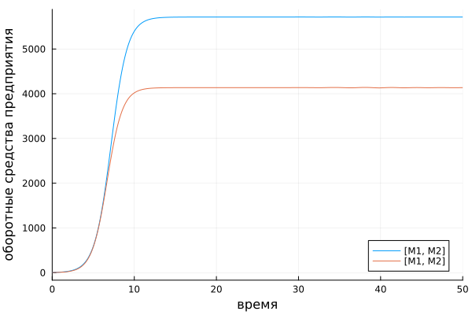

Рисунок 2: График изменения оборотных средств фирм для первого случая

## Выполнение лабораторной работы

Написала несколько строк, чтобы получить максимальные значения, которые оба фирмы достигли:

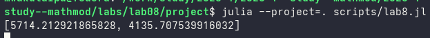

Рисунок 3: Максимальное значение М1 и М2

## Выполнение лабораторной работы

Я выполнила скрипт для второго случая с такими же параметрами, как в первом случае и построила его график (рис. 4).

```julia
function f2(du, u, p, t)
    a1, a2, b, c1, c2 = p
    du[1] = u[1] - (a1/c1)*u[1]*u[1] - (b/c1)*u[1]*u[2]
    du[2] = (c2/c1)*u[2] - (b/c1+0.00094)*u[1]*u[2] - (a2/c1)*u[2]*u[2]
end
```

## Выполнение лабораторной работы

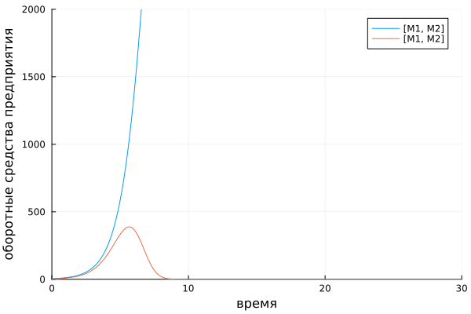

Рисунок 4: График изменения оборотных средств фирм для второго случая

# Выводы

При выполнении данной работы я построила модели конкуренции для двух фирм для двух разных случаях.